# Tugas_APG_8

Bill Van Ricardo Zalukhu

2022-04-20

```r
library(factoextra)
library(dplyr)
```

## 8.11

```r
tot_pop <- c(5.935, 1.523, 2.599, 4.009, 4.687, 8.044, 2.766, 6.538, 6.451, 3.314, 3.777, 1.530, 2.768, 6.585)
med_school_year <- c(14.2, 13.1, 12.7, 15.2, 14.7, 15.6, 13.3, 17, 12.9, 12.2, 13, 13.8, 13.6, 14.9)
tot_emp <- c(2.265, .597, 1.237, 1.649, 2.312, 3.641, 1.244, 2.618, 3.147, 1.606, 2.119, .798, 1.336, 2.763)
health_ser <- c(2.27, .75, 1.11, .81, 2.5, 4.51, 1.03, 2.39, 5.52, 2.18, 2.83, .84, 1.75, 1.91)
med_val_home <- c(29.1, 26.2, 17.2, 30.2, 22.2, 23.6, 19.7, 18.5, 20.1, 18.2, 18, 42.5, 26.4, 31.7)

cen_tract <- cbind(tot_pop, med_school_year, tot_emp, health_ser, med_val_home)
```

```r
S_cen <- cov(cen_tract)
S_cen
```

```
##                   tot_pop med_school_year    tot_emp health_ser med_val_home
## tot_pop          4.307556       1.6836802  1.8027760   2.155326    -2.534744
## med_school_year  1.683680       1.7674725  0.5880264   0.177978     1.755495
## tot_emp          1.802776       0.5880264  0.8006685   1.064828    -1.583390
## health_ser       2.155326       0.1779780  1.0648280   1.969475    -3.568066
## med_val_home    -2.534744       1.7554945 -1.5833901  -3.568066    50.438022
```

Pada bagian ini, saya menggunakan data dengan variabel ke lima yang sudah diskala ulang (dikalikan dengan 10). Jika pada soal, hal itu bisa dilakukan karena data kelima akan diskala ulang, yang mengakibatkan semua elemen pada matriks kovarian yang mengandung variabel ke lima akan terkena efek penskalaan ulang tersebut. Untuk elemen yang mengandung satu data variabel kelima (yaitu elemen kovarians) akan dikalikan 10 karena perubahan berbanding lurus dengan data, sedangkan untuk varians nya sendiri dikalikan dengan 100 karena bentuk dari varians sendiri merupakan bentuk kuadrat, sehingga jika terjadi perubahan skala pada datanya akan dikuadratkan (dalam hal ini karena data akan dikalikan 10, karena bentuk kuadrat, maka akan dikalikan kuadrat dari 10, yaitu 100).

```r
eig_cen <- eigen(S_cen)
eig_val_cen <- eig_cen$values
eig_vec_cen <- eig_cen$vectors
```

```r
eig_vec_cen
```

```
##             [,1]       [,2]        [,3]         [,4]         [,5]
## [1,]  0.05765977 0.78220765  0.02307185  0.541282426 -0.302171422
## [2,] -0.03281610 0.35032828  0.76422159 -0.540439691 -0.009137870
## [3,]  0.03467366 0.32717525 -0.10109097  0.051177198  0.937504990
## [4,]  0.07557524 0.39085238 -0.63207658 -0.642117054 -0.172301138
## [5,] -0.99432619 0.07491367 -0.07545108  0.002204195  0.002375237
```

```r
eig_val_cen
```

```
## [1] 50.96935726  6.64988991  1.41999710  0.22978608  0.01416317
```

```r
eig_vec_cen
```

```
##             [,1]       [,2]        [,3]         [,4]         [,5]
## [1,]  0.05765977 0.78220765  0.02307185  0.541282426 -0.302171422
## [2,] -0.03281610 0.35032828  0.76422159 -0.540439691 -0.009137870
## [3,]  0.03467366 0.32717525 -0.10109097  0.051177198  0.937504990
## [4,]  0.07557524 0.39085238 -0.63207658 -0.642117054 -0.172301138
## [5,] -0.99432619 0.07491367 -0.07545108  0.002204195  0.002375237
```

```r
prop_var_cen <- c()
temp <- 0

for (i in c(1:5)){
  temp <- temp + eig_val_cen[i]
  prop_var <- (temp / sum(eig_val_cen)) * 100
  prop_var_cen <- append(prop_var_cen, prop_var)
}
prop_var_cen
```

```
## [1]  85.97607  97.19322  99.58850  99.97611 100.00000
```

```r
rho_cen <- matrix(nrow = 5, ncol = 5)
for (i in c(1:5)){
  for(j in c(1:5)){
    rho_cen[j, i] <- (eig_vec_cen[j, i] * sqrt(eig_val_cen[i]))/sqrt(S_cen[j, j])
  }
}
rho_cen
```

```
##            [,1]       [,2]        [,3]         [,4]          [,5]
## [1,]  0.1983408 0.97188266  0.01324679  0.125017363 -1.732679e-02
## [2,] -0.1762240 0.67952602  0.68499389 -0.194864516 -8.179916e-04
## [3,]  0.2766482 0.94289056 -0.13462624  0.027416498  1.246888e-01
## [4,]  0.3844669 0.71819899 -0.53670819 -0.219331425 -1.461144e-02
## [5,] -0.9995498 0.02720128 -0.01265990  0.000148776  3.980229e-05
```

Dengan adanya perubahan skala yang dilakukan pada variabel ke lima, terlihat bahwa terjadi juga perubahan pada eigenvalue dan eigenvector dari data, dibandingkan dengan contoh 8.3. Selain kedua nilai itu, terlihat juga bahwa terjadi perubahan pada nilai-nilai korelasi parsial terhadap nilai-nilai yang bersesuaian.

## 8.12

```r
wind <- c(8, 7, 7, 10, 6, 8, 9, 5, 7, 8, 6, 6, 7, 10, 10, 9, 8, 8, 9, 9, 10, 9, 8, 5, 6, 8, 6, 8, 6, 10, 8, 7, 5, 6, 10, 8, 5, 5, 7, 7, 6, 8)
solar_rad <- c(98, 107, 103, 88, 91, 90, 84, 72, 82, 64, 71, 91, 72, 70, 72, 77, 76, 71, 67, 69, 62, 88, 80, 30, 83, 84, 78, 79, 62, 37, 71, 52,
             48, 75, 35, 85, 86, 86, 79, 79, 68, 40)
co <- c(7, 4, 4, 5, 4, 5, 7, 6, 5, 5, 5, 4, 7, 4, 4, 4, 4, 5, 4, 3, 5, 4, 4, 3, 5, 3, 4, 2, 4, 3, 4, 4, 6, 4, 4, 4, 3, 7, 7, 5, 6, 4)
no <- c(2, 3, 3, 2, 2, 2, 4, 4, 1, 2, 4, 2, 4, 2, 1, 1, 1, 3, 2, 3, 3, 2, 2, 3, 1, 2, 2, 1, 3, 1, 1, 1, 5, 1, 1, 1, 1, 2, 4, 2, 2, 3)
no_2 <- c(12, 9, 5, 8, 8, 12, 12, 21, 11, 13, 10, 12, 18, 11, 8, 9, 7, 16, 13, 9, 14, 7, 13, 5, 10, 7, 11, 7, 9, 7, 10, 12, 8, 10, 6, 9, 6, 13, 9, 8, 11, 6)
o_3 <- c(8, 5, 6, 15, 10, 12, 15, 14, 11, 9, 3, 7, 10, 7, 10, 10, 7, 4, 2, 5, 4, 6, 11, 2, 23, 6, 11, 10, 8, 2, 7, 8, 4, 24, 9, 10, 12, 18, 25, 6, 14, 5)
hc <- c(2, 3, 3, 4, 3, 4, 5, 4, 3, 4, 3, 3, 3, 3, 3, 3, 3, 4, 3, 3, 4, 3, 4, 3, 4, 3, 3, 3, 3, 3, 3, 4, 3, 3, 2, 2, 2, 2, 3, 2, 3, 2)

air_pollution <- cbind(wind, solar_rad, co, no, no_2, o_3, hc)
```

```r
S_pollution <- cov(air_pollution)
S_pollution
```

```
##                 wind   solar_rad         co         no       no_2        o_3
## wind       2.5000000  -2.7804878 -0.3780488 -0.4634146 -0.5853659 -2.2317073
## solar_rad -2.7804878 300.5156794  3.9094077 -1.3867596  6.7630662 30.7909408
## co        -0.3780488   3.9094077  1.5220674  0.6736353  2.3147503  2.8217189
## no        -0.4634146  -1.3867596  0.6736353  1.1823461  1.0882695 -0.8106852
## no_2      -0.5853659   6.7630662  2.3147503  1.0882695 11.3635308  3.1265970
## o_3       -2.2317073  30.7909408  2.8217189 -0.8106852  3.1265970 30.9785134
## hc         0.1707317   0.6236934  0.1416957  0.1765389  1.0441347  0.5946574
##                  hc
## wind      0.1707317
## solar_rad 0.6236934
## co        0.1416957
## no        0.1765389
## no_2      1.0441347
## o_3       0.5946574
## hc        0.4785134
```

```r
cor(air_pollution)
```

```
##                 wind   solar_rad         co          no       no_2        o_3
## wind       1.0000000 -0.10144191 -0.1938032 -0.26954261 -0.1098249 -0.2535928
## solar_rad -0.1014419  1.00000000  0.1827934 -0.07356907  0.1157320  0.3191237
## co        -0.1938032  0.18279338  1.0000000  0.50215246  0.5565838  0.4109288
## no        -0.2695426 -0.07356907  0.5021525  1.00000000  0.2968981 -0.1339521
## no_2      -0.1098249  0.11573199  0.5565838  0.29689814  1.0000000  0.1666422
## o_3       -0.2535928  0.31912373  0.4109288 -0.13395214  0.1666422  1.0000000
## hc         0.1560979  0.05201044  0.1660323  0.23470432  0.4477678  0.1544506
##                   hc
## wind      0.15609793
## solar_rad 0.05201044
## co        0.16603235
## no        0.23470432
## no_2      0.44776780
## o_3       0.15445056
## hc        1.00000000
```

```r
eig_poll_cov <- eigen(S_pollution)
```

```r
eig_val_cov <- eig_poll_cov$values
eig_vec_cov <- eig_poll_cov$vectors
```

```r
eig_val_cov
```

```
## [1] 304.2578640  28.2761046  11.4644830   2.5243296   1.2795247   0.5287288
## [7]   0.2096157
```

```r
eig_vec_cov
```

```
##              [,1]        [,2]        [,3]          [,4]          [,5]
## [1,]  0.010039244  0.07622439  0.03087761  0.9203045748  0.3423859285
## [2,] -0.993199405  0.11615518  0.00659069 -0.0002118679  0.0022391022
## [3,] -0.014062314 -0.09956775 -0.18282641 -0.1382922410  0.6500776063
## [4,]  0.004710175  0.01320423 -0.13021553 -0.3277842624  0.6431560485
## [5,] -0.024255644 -0.15038113 -0.95526318  0.1023719020 -0.2065840405
## [6,] -0.112429558 -0.97335904  0.16981025  0.0632480276 -0.0002935726
## [7,] -0.002340785 -0.02382046 -0.08519558  0.1095073458  0.0619613872
##              [,6]         [,7]
## [1,]  0.011779079 -0.169729925
## [2,]  0.003353218 -0.001781987
## [3,] -0.563893916  0.443577538
## [4,]  0.497513370 -0.462855916
## [5,] -0.009009299 -0.105029951
## [6,]  0.051067254 -0.066992404
## [7,]  0.657012233  0.738019426
```

- Analysis menggunakan matriks kovarian
1. Manual

```r
prop_var_poll_cov <- c()
temp <- 0

for (i in c(1:7)){
  temp <- temp + eig_val_cov[i]
  prop_var <- (temp / sum(eig_val_cov)) * 100
  prop_var_poll_cov <- append(prop_var_poll_cov, prop_var)
}
prop_var_poll_cov
```

```
## [1]  87.29480  95.40751  98.69680  99.42105  99.78816  99.93986 100.00000
```

```r
rho_poll_cov <- matrix(nrow = 7, ncol = 7)
for (i in c(1:7)){
  for(j in c(1:7)){
    rho_poll_cov[j, i] <- (eig_vec_cov[j, i] * sqrt(eig_val_cov[i]))/sqrt(S_pollution[j, j])
  }
}
rho_poll_cov
```

```
##             [,1]        [,2]         [,3]          [,4]          [,5]
## [1,]  0.11075209  0.25635026  0.066122757  9.247719e-01  2.449459e-01
## [2,] -0.99936420  0.03562992  0.001287285 -1.941801e-05  1.461049e-04
## [3,] -0.19882031 -0.42915242 -0.501763680 -1.780959e-01  5.960361e-01
## [4,]  0.07555890  0.06457294 -0.405478384 -4.789485e-01  6.690651e-01
## [5,] -0.12550964 -0.23721736 -0.959497022  4.824998e-02 -6.932094e-02
## [6,] -0.35234744 -0.92993495  0.103302503  1.805468e-02 -5.966361e-05
## [7,] -0.05902492 -0.18311035 -0.417010749  2.515181e-01  1.013208e-01
##               [,6]          [,7]
## [1,]  0.0054169873 -4.914738e-02
## [2,]  0.0001406516 -4.706335e-05
## [3,] -0.3323509745  1.646131e-01
## [4,]  0.3326970328 -1.948881e-01
## [5,] -0.0019433492 -1.426489e-02
## [6,]  0.0066715801 -5.510705e-03
## [7,]  0.6906259742  4.884641e-01
```

```r
components <- matrix(nrow = 42, ncol = 7)
for(i in c(1:7)){
  for(j in c(1:42)){
    components[j, i] <- t(eig_vec_cov[,i]) %*% air_pollution[j, ]
  }
}
```

2. Dengan Package

```r
pca_poll_cov <- prcomp(air_pollution, scale = FALSE)
```

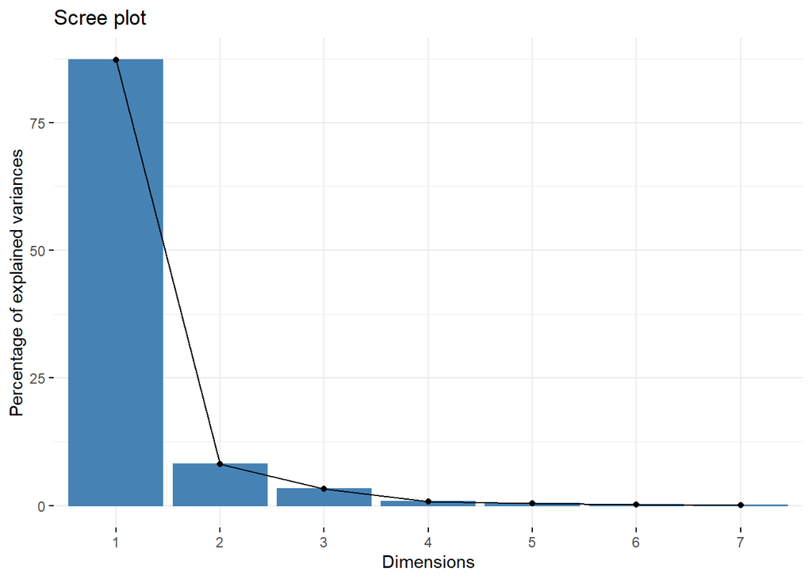

```r
fviz_eig(pca_poll_cov)
```

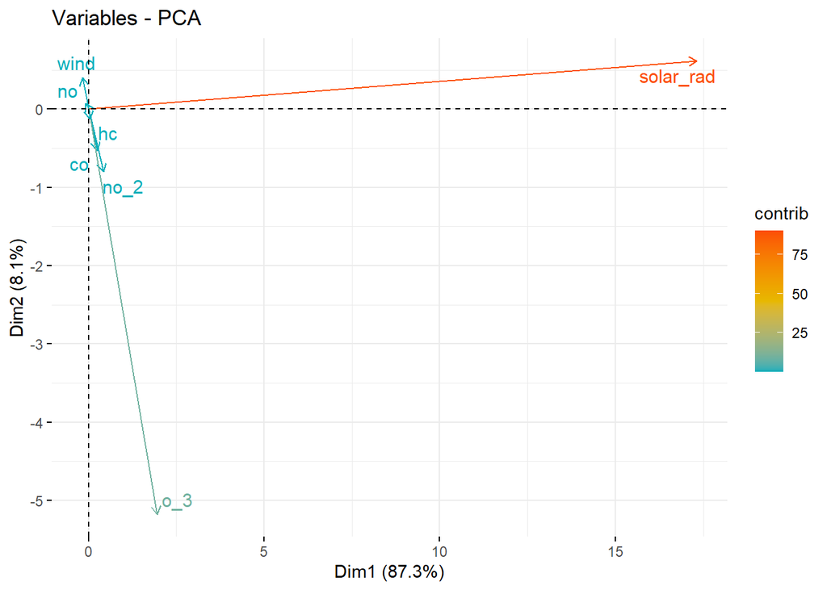

```r
fviz_pca_var(pca_poll_cov,
             col.var = "contrib", # Color by contributions to the PC
             gradient.cols = c("#00AFBB", "#E7B800", "#FC4E07"),
             repel = TRUE     # Avoid text overlapping
             )
```

- Menggunakan Matriks Korelasi

```r
pollution_norm <- as.data.frame(air_pollution) %>% mutate_all(~(scale(.) %>% as.vector))
```